# Fundamentals of Data Visualization and Communication in Dementia Research

A hands-on workshop using the SEA-AD cognitive scores dataset

Suh Young Choi

# Welcome!

In this coding demo, we’ll practice building and *critiquing* data visualizations in R using `ggplot2`, with a real longitudinal cognitive-aging dataset. Each exercise in this Rmarkdown file is guided, so you can complete them on your own time outside the workshop as well. By the end of the workshop you will be able to:

1. Build the core plot types in `ggplot2` (scatter, line, bar, histogram).
2. Choose an appropriate visualization for a scientific question and variables of interest.
3. Recognize and fix common visualization mistakes (sub-optimal color choices, overcrowding, missing labels).
4. Apply accessibility principles so your figures work for colorblind readers, low-vision readers, and greyscale printing.

Work through the code chunks in order. Chunks marked **YOUR TURN** are exercises — replace the `___` placeholders with your own code. There is no single correct answer for most exercises; the goal is practice and discussion.

# 0. Setup and data

```r
library(tidyverse)    # ggplot2, dplyr, etc.
library(viridis)      # colorblind-safe, perceptually uniform palettes
library(scales)       # nice axis labels
```

## 0.1 Load the data

```r
cog <- read_csv("sea-ad_cohort_harmonized_cognitive_scores_20241213.csv")
cog <- cog %>% select(-`...1`)  # drop leftover index column from the spreadsheet
glimpse(cog)
```

```
## Rows: 639
## Columns: 17
## $ study            <chr> "ACT", "ACT", "ACT", "ACT", "ACT", "ACT", "ACT", "ACT…
## $ visit            <dbl> 0, 2, 5, 6, 9, 11, 0, 2, 4, 6, 8, 10, 12, 14, 15, 0, …
## $ age_vis          <dbl> 67, 69, 71, 74, 76, 78, 77, 79, 81, 83, 85, 87, 88, 9…
## $ MEM_E            <dbl> 0.570, 0.608, 1.294, 1.107, 0.622, 0.177, 0.570, 1.10…
## $ MEM_E_SE         <dbl> 0.460, 0.164, 0.249, 0.546, 0.445, 0.387, 0.460, 0.54…
## $ EXF_E            <dbl> 0.690, 0.182, 0.176, 0.690, 0.477, -0.204, 0.681, -0.…
## $ EXF_E_SE         <dbl> 0.587, 0.343, 0.422, 0.587, 0.598, 0.556, 0.578, 0.53…
## $ LAN_E            <dbl> 0.151, 0.067, 0.374, 0.045, 0.045, 0.045, -0.047, 0.0…
## $ LAN_E_SE         <dbl> 0.530, 0.389, 0.507, 0.551, 0.551, 0.551, 0.477, 0.55…
## $ VSP_E            <dbl> 0.609, 1.196, 0.435, 0.609, 0.609, 0.609, 0.609, 0.60…
## $ VSP_E_SE         <dbl> 0.859, 0.729, 0.697, 0.859, 0.859, 0.859, 0.859, 0.85…
## $ slope_zmem0      <dbl> -0.0544588, -0.0544588, -0.0544588, -0.0544588, -0.05…
## $ slope_zexf0      <dbl> -0.0613221, -0.0613221, -0.0613221, -0.0613221, -0.06…
## $ slope_zlan0      <dbl> -0.0813360, -0.0813360, -0.0813360, -0.0813360, -0.08…
## $ slope_zvsp0      <dbl> -0.0109903, -0.0109903, -0.0109903, -0.0109903, -0.01…
## $ slope_zcasi_irt0 <dbl> -0.0793083, -0.0793083, -0.0793083, -0.0793083, -0.07…
## $ `Donor ID`       <chr> "H20.33.044", "H20.33.044", "H20.33.044", "H20.33.044…
```

## 0.2 What are we looking at?

This is the **SEA-AD cohort harmonized cognitive scores** dataset: repeated-visit cognitive testing data from two longitudinal aging studies.

| Column | Meaning |
| --- | --- |
| `study` | Cohort: `ACT` (Adult Changes in Thought) or `UWADRC` (UW Alzheimer’s Disease Research Center) |
| `Donor ID` | Unique participant identifier |
| `visit` | Time since baseline visit, in years |
| `age_vis` | Participant’s age at that visit |
| `MEM_E`, `EXF_E`, `LAN_E`, `VSP_E` | Harmonized domain scores: **Mem**ory, **Ex**ecutive **F**unction, **Lan**guage, **V**isuo**sp**atial (higher = better performance) |
| `MEM_E_SE`, etc. | Standard error of each domain score |
| `slope_zmem0`, etc. | Each donor’s estimated rate of cognitive decline per domain (negative = declining) |

Each row is one **visit**; each donor contributes multiple rows over time. Keep that nested structure in mind! It will matter when we build line plots and when we think about overplotting.

```r
n_distinct(cog$`Donor ID`)
```

```
## [1] 81
```

```r
table(cog$study)
```

```
##
##    ACT UWADRC
##    551     88
```

# Part 1: Intro to `ggplot2`

`ggplot2` builds plots in layers: you start with data + an aesthetic mapping (`aes()`), then add a “geom” parameter that says how to draw it.

```r
ggplot(data, aes(x = ..., y = ...)) +
  geom_point()   # or geom_line(), geom_bar(), geom_histogram(), etc.
```

## 1.1 Scatter plot

Question: does memory performance relate to age at visit?

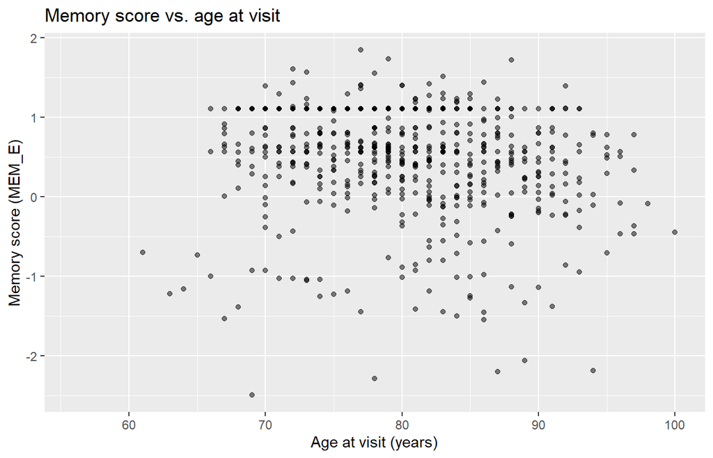

```r
ggplot(cog, aes(x = age_vis, y = MEM_E)) +
  geom_point(alpha = 0.5) +
  labs(title = "Memory score vs. age at visit",
       x = "Age at visit (years)",
       y = "Memory score (MEM_E)") # the labs parameter lets us title the plot and axes
```

**Reflect:** Do you see a relationship? Is it linear? What does each *point* represent here — a donor, or a visit? Does that change how you’d interpret the scatter?

- Replace this line with your thoughts

## 1.2 Line plot

Question: how does one donor’s memory score change over time?

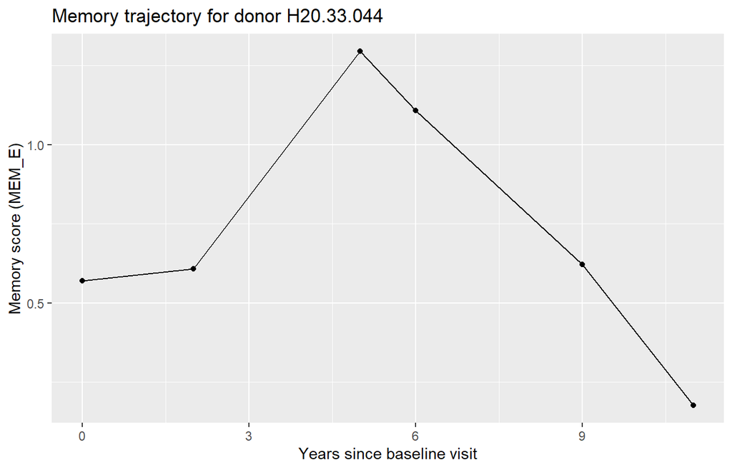

```r
one_donor <- cog %>% filter(`Donor ID` == "H20.33.044")

ggplot(one_donor, aes(x = visit, y = MEM_E)) +
  geom_line() +
  geom_point() +
  labs(title = "Memory trajectory for donor H20.33.044",
       x = "Years since baseline visit",
       y = "Memory score (MEM_E)")
```

**Reflect:** A line plot implies a connected, ordered sequence. Would a line plot make sense if `x` were `study` instead of `visit`? Why or why not?

- Replace this line with your thoughts

## 1.3 Bar plot

Question: how many visits were recorded in each study?

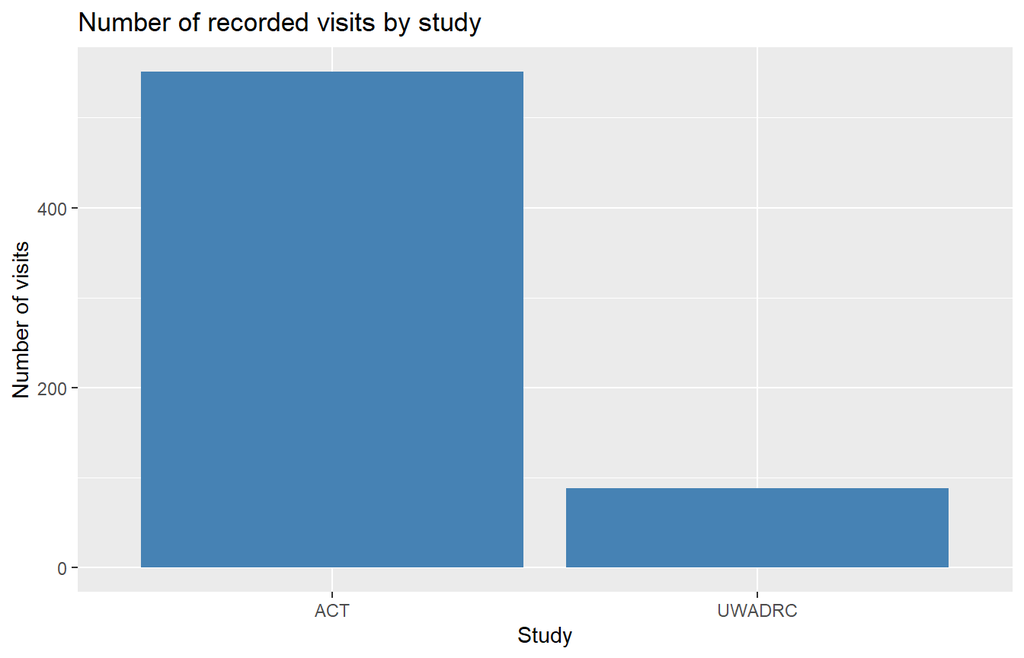

```r
ggplot(cog, aes(x = study)) +
  geom_bar(fill = "steelblue") +
  labs(title = "Number of recorded visits by study",
       x = "Study",
       y = "Number of visits")
```

**Reflect:** `geom_bar()` counts rows by default. What would change if you used `geom_col()` instead? (Hint: look up the difference! It matters once you’re plotting a *summary* value like a mean rather than a count.)

- Replace this line with your thoughts

## 1.4 Histogram

Question: what’s the distribution of memory scores across all visits?

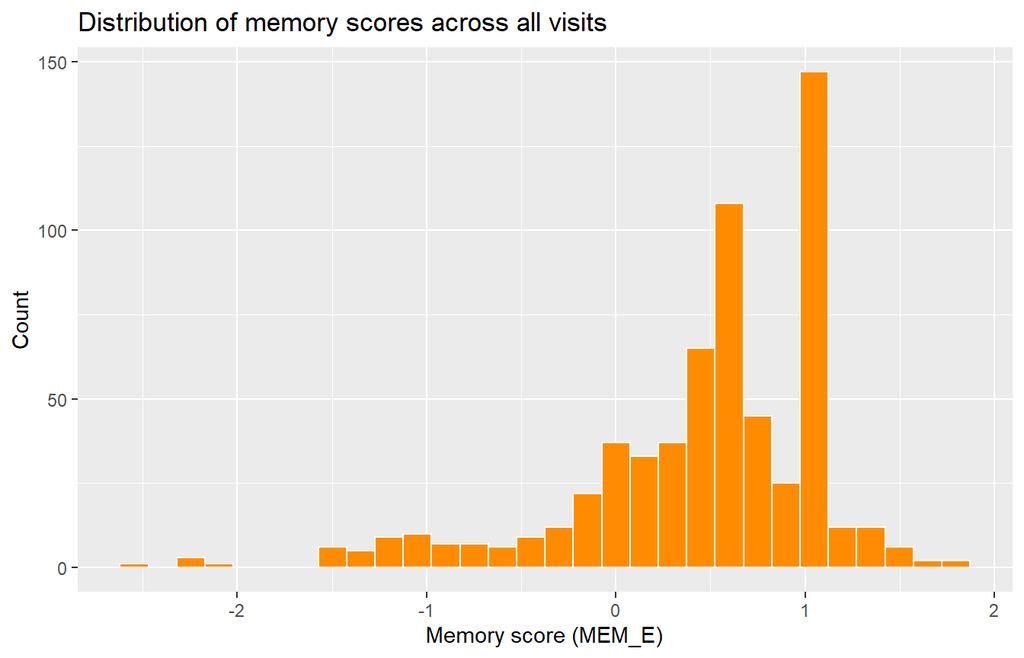

```r
ggplot(cog, aes(x = MEM_E)) +
  geom_histogram(bins = 30, fill = "darkorange", color = "white") +
  labs(title = "Distribution of memory scores across all visits",
       x = "Memory score (MEM_E)",
       y = "Count")
```

**Reflect:** Try changing `bins = 30` to `bins = 5` and then `bins = 100`. How does bin width change the story the histogram tells? Is there a “right” number of bins?

```r
# YOUR TURN: try a few different bin counts and see how the shape changes
# You can also try different fill and color values! See https://r-graph-gallery.com/42-colors-names.html for some ideas

ggplot(cog, aes(x = MEM_E)) +
  geom_histogram(bins = ___, fill = "darkorange", color = "white")
```

# Part 2: Visualizing relationships between variables

Now it’s your turn to make a choice. This dataset has several variable “families”:

- **Cognitive domain scores**: `MEM_E`, `EXF_E`, `LAN_E`, `VSP_E`
- **Time/age**: `visit`, `age_vis`
- **Grouping variables**: `study`, `Donor ID`
- **Decline slopes**: `slope_zmem0`, `slope_zexf0`, `slope_zlan0`, `slope_zvsp0`, `slope_zcasi_irt0`

## 2.1 YOUR TURN: pick a plot type and variables

Choose **one plot type** from Part 1 (scatter, line, bar, or histogram) and **one pair (or more) of variables** you’re curious about. Here are some starter ideas if you’re stuck; feel free to come up with your own!

- Does executive function (`EXF_E`) relate to language score (`LAN_E`)?
- Do memory decline slopes (`slope_zmem0`) differ by `study`?
- How does visuospatial score (`VSP_E`) change with `age_vis`, colored by `study`?

```r
# YOUR TURN
ggplot(cog, aes(x = ___, y = ___)) +
  geom____() +
  labs(title = "___",
       x = "___",
       y = "___")
```

**Discuss with your neighbor:**

1. Why did you choose this plot type for these variables? Would a different geom have worked as well, or better?
2. Is there a real scientific question this plot could speak to (e.g., “does executive function decline track with memory decline?”)?
3. What does the plot *not* tell you? What additional variable (e.g., `age_vis`, `study`) might you want to add as a color or facet?

# Part 3: Fixing ineffective visualizations

## 3.1: A poor color palette

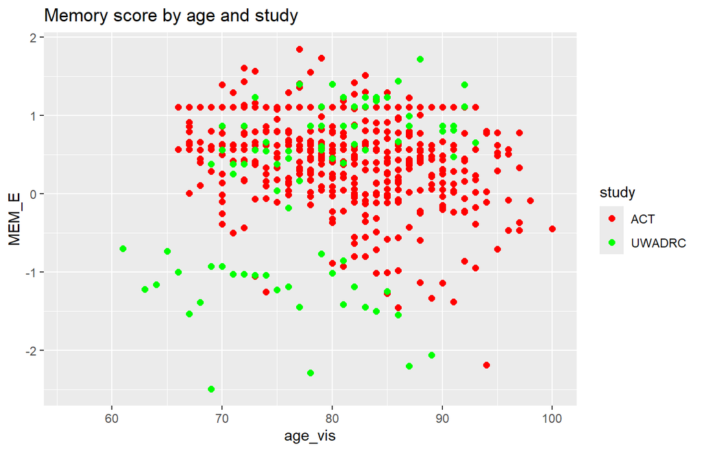

```r
ggplot(cog, aes(x = age_vis, y = MEM_E, color = study)) +
  geom_point(size = 2) +
  scale_color_manual(values = c("ACT" = "red", "UWADRC" = "green")) +
  labs(title = "Memory score by age and study")
```

**What’s wrong?** Red/green is one of the hardest color pairs for colorblind readers to distinguish (the most common form of color vision deficiency is red-green), and it won’t survive greyscale printing either. Let’s find some better contrasting colors. (You can check out the R-charts [color palettes](https://r-charts.com/color-palettes/) for inspiration!)

```r
# YOUR TURN: replace the color scale with a colorblind-safe option, e.g.
# scale_color_viridis_d() or scale_color_brewer(palette = "Dark2")
ggplot(cog, aes(x = age_vis, y = MEM_E, color = study)) +
  geom_point(size = 2) +
  ___ +
  labs(title = "Memory score by age and study")
```

## 3.2 Problem: Overcrowding

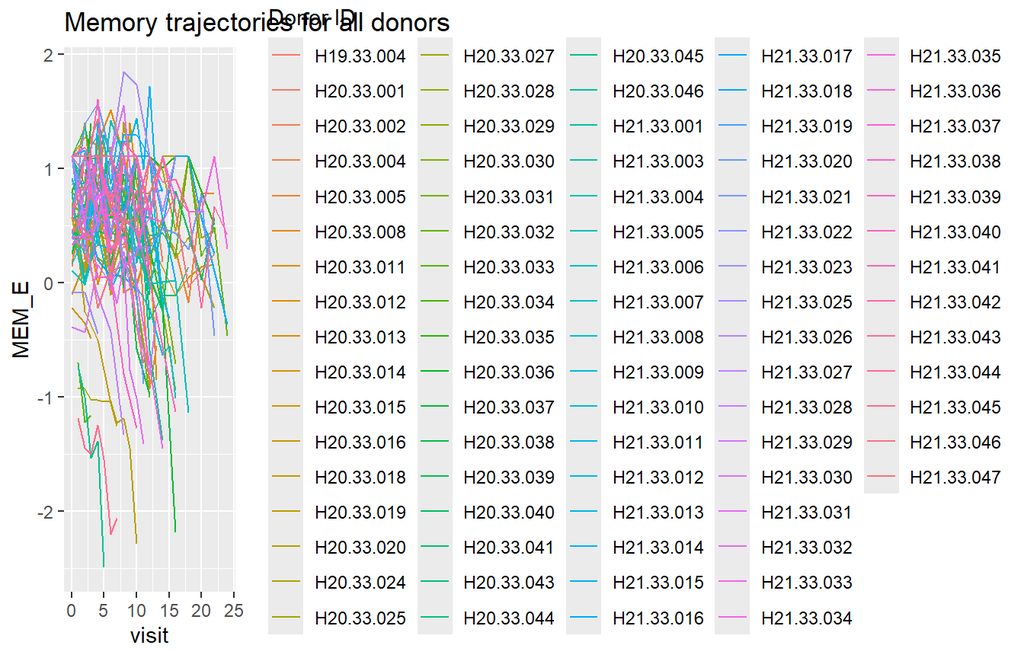

```r
ggplot(cog, aes(x = visit, y = MEM_E, color = `Donor ID`, group = `Donor ID`)) +
  geom_line() +
  labs(title = "Memory trajectories for all donors")
```

**What’s wrong?** With 81 donors, `ggplot2` can’t even fit a usable legend, and the plot is a tangle of overlapping lines. We call this a “spaghetti plot” where no individual trajectory is readable and no overall pattern is visible either.

A few common fixes for overcrowding: reduce opacity (`alpha`), subsample the donors shown, facet into small multiples, or summarize (e.g., a mean trend line with a ribbon for variability) instead of showing every raw line.

```r
# YOUR TURN: try one (or more) of these fixes.
# Option A: lower alpha and drop the legend
ggplot(cog, aes(x = visit, y = MEM_E, group = `Donor ID`)) +
  geom_line(alpha = ___, color = "steelblue") +
  labs(title = "Memory trajectories for all donors",
       x = "Years since baseline", y = "Memory score (MEM_E)")

# Option B: facet by study instead of coloring by every donor
ggplot(cog, aes(x = visit, y = MEM_E, group = `Donor ID`)) +
  geom_line(alpha = 0.3, color = "steelblue") +
  facet_wrap(~ ___) +
  labs(title = "Memory trajectories by study")

# Option C: show the summary trend instead of every donor
ggplot(cog, aes(x = visit, y = MEM_E)) +
  stat_summary(fun = mean, geom = "line", color = "darkred", linewidth = 1) +
  stat_summary(fun.data = mean_se, geom = "ribbon", alpha = 0.2) +
  labs(title = "Average memory trajectory across donors (± SE)")
```

## 3.3 Problem: Missing labels

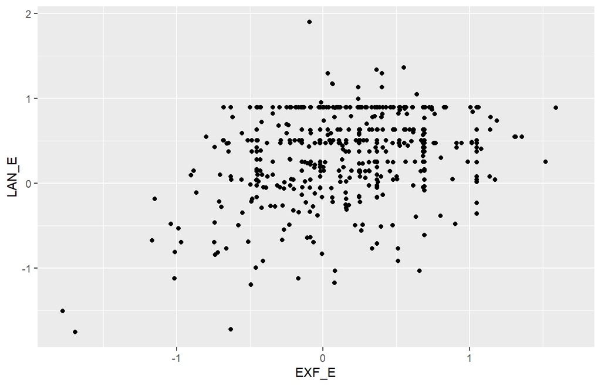

```r
ggplot(cog, aes(x = EXF_E, y = LAN_E)) +
  geom_point()
```

**What’s wrong?** Without a title or labeled, unit-bearing axes, a reader (especially one seeing this figure out of context in a paper, a slide, or a screen reader) has no way to know what `EXF_E` and `LAN_E` mean or why the plot exists.

```r
# YOUR TURN: add a title, x label, and y label
ggplot(cog, aes(x = EXF_E, y = LAN_E)) +
  geom_point(alpha = 0.5) +
  labs(title = "___",
       x = "___",
       y = "___")
```

**Discuss:** What makes a title *informative* rather than just descriptive? Compare `"Executive function vs. language score"` to something like `"Executive function and language scores are positively correlated across visits"`. Which communicates more on its own, without reading the surrounding text?

# Part 4: Ensuring visual accessibility

Fixing individual mistakes is a start, but accessibility is a design habit, not a single fix. A few core principles:

## 4.1 Use colorblind-safe, perceptually uniform palettes

Roughly 1 in 12 men and 1 in 200 women have some form of color vision deficiency. Default `ggplot2` colors (the “rainbow” hue wheel) and manually-picked colors like pure red/green are risky. Instead, you can try using:

- `scale_color_viridis_d()` / `scale_fill_viridis_d()` (discrete) or `scale_color_viridis_c()` (continuous) — perceptually uniform and colorblind-safe by design.
- `scale_color_brewer(palette = "Dark2")` or `"Set2"` from ColorBrewer

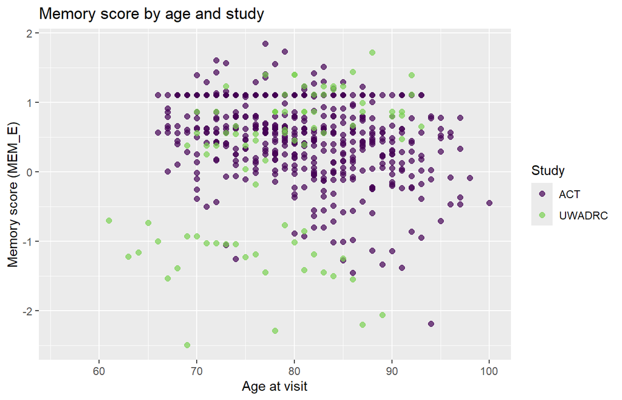

```r
ggplot(cog, aes(x = age_vis, y = MEM_E, color = study)) +
  geom_point(size = 2, alpha = 0.7) +
  scale_color_viridis_d(end = 0.8) +
  labs(title = "Memory score by age and study",
       x = "Age at visit", y = "Memory score (MEM_E)",
       color = "Study")
```

## 4.2 Don’t rely on color alone

Pair color with a second visual channel such as shape, line type, or direct labels so that the plot still works in greyscale or for a colorblind reader.

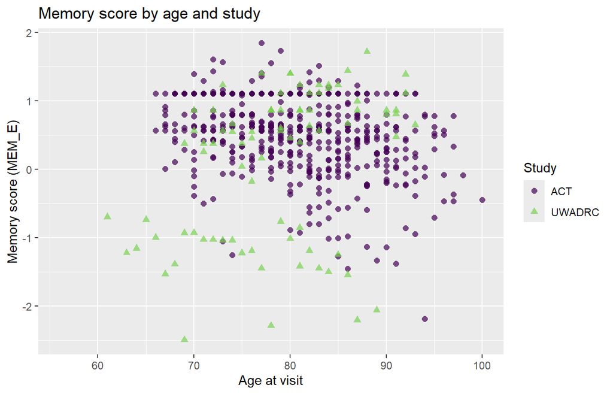

```r
ggplot(cog, aes(x = age_vis, y = MEM_E, color = study, shape = study)) +
  geom_point(size = 2, alpha = 0.7) +
  scale_color_viridis_d(end = 0.8) +
  labs(title = "Memory score by age and study",
       x = "Age at visit", y = "Memory score (MEM_E)",
       color = "Study", shape = "Study")
```

## 4.3 Readable text

Small default text is a common accessibility failure for people with low vision, for a room where slides are projected, or for a figure shrunk down in a paper. Increase the base font size and make sure titles/labels are never left at defaults.

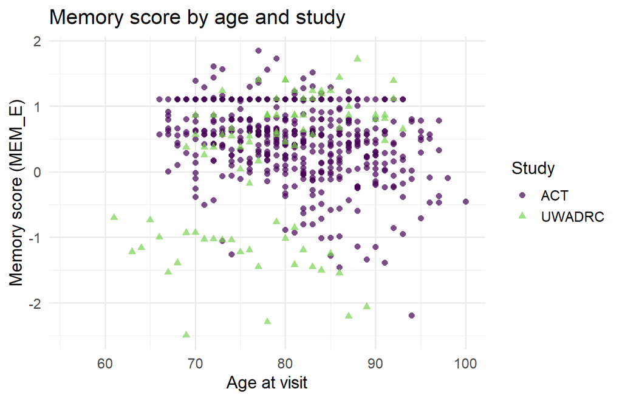

```r
ggplot(cog, aes(x = age_vis, y = MEM_E, color = study, shape = study)) +
  geom_point(size = 2, alpha = 0.7) +
  scale_color_viridis_d(end = 0.8) +
  labs(title = "Memory score by age and study",
       x = "Age at visit", y = "Memory score (MEM_E)",
       color = "Study", shape = "Study") +
  theme_minimal(base_size = 14)
```

## 4.4 Write alt text for your figures

If this were a knitted HTML/PDF report or a slide, a screen-reader user relies entirely on **alt text** to know what the figure shows. In R Markdown you can set this per chunk with `fig.alt`:

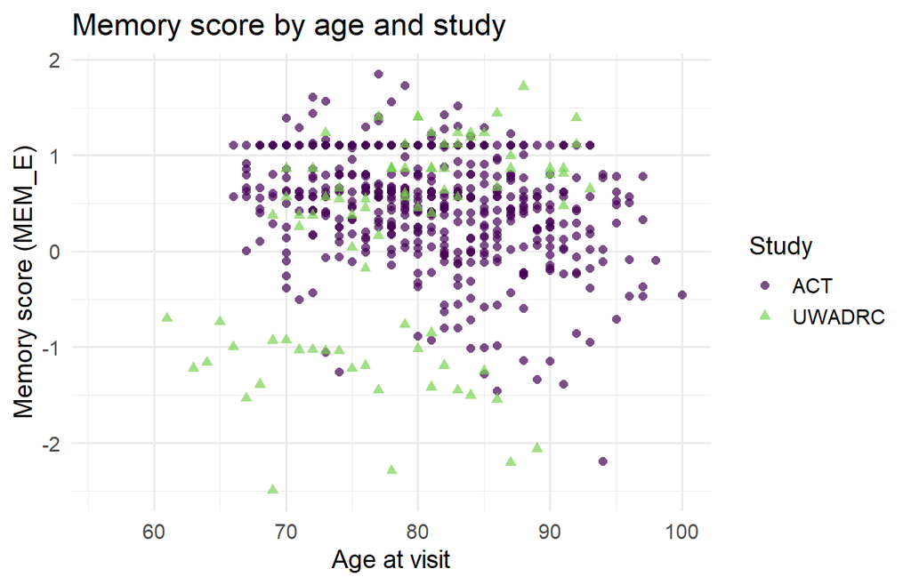

```r
ggplot(cog, aes(x = age_vis, y = MEM_E, color = study, shape = study)) +
  geom_point(size = 2, alpha = 0.7) +
  scale_color_viridis_d(end = 0.8) +
  theme_minimal(base_size = 14) +
  labs(title = "Memory score by age and study",
       x = "Age at visit", y = "Memory score (MEM_E)",
       color = "Study", shape = "Study")
```

## 4.5 YOUR TURN: build an accessible figure from scratch

Take the plot you built in **Part 2** (or one of the “fixed” plots from Part 3) and apply everything from this section:

```r
# YOUR TURN — checklist:
# [ ] colorblind-safe palette (viridis or ColorBrewer)
# [ ] a second encoding (shape/linetype) if color distinguishes groups
# [ ] readable font size (theme_minimal(base_size = 14) or similar)
# [ ] informative title + labeled, unit-bearing axes
# [ ] fig.alt describing the pattern, set in the chunk options

ggplot(cog, aes(x = ___, y = ___)) +
  geom____() +
  scale_color_viridis_d() +
  theme_minimal(base_size = 14) +
  labs(title = "___", x = "___", y = "___")
```

# Wrap-up discussion

- Which of today’s four accessibility fixes (palette, redundant encoding, text size, alt text) do you think you’re *least* likely to remember to do by default? Why?
- Looking back at a figure you’ve made for a paper or poster before this workshop — would it survive being converted to greyscale? Would it make sense to a colorblind reviewer?
- For your own Alzheimer’s/cognitive aging data: which variable pairs are you most excited to visualize now, and what pitfalls from Part 3 will you watch for?